# **dbverse**: composable database libraries for larger-than-memory scientific analytics

Edward C. Ruiz

ecruiz@bu.edu

Ph.D. Candidate, Dries Lab, Boston University

August 15, 2024

## Motivation

### Current challenges with scientific data analysis

- Scientific data is often messy and complex.
  - Not your standard dataframe
  - Heterogeneous, multi-modal (e.g. “multi-omics”)
  - Larger-than-memory (e.g. spatial multi-omics)
- A variety of tools and languages are used to analyze scientific data.
  - Interoperability is often limited
  - Fragmentation by data type
- **How can we develop better approaches for scientific data analysis?**

## *dbverse* overview

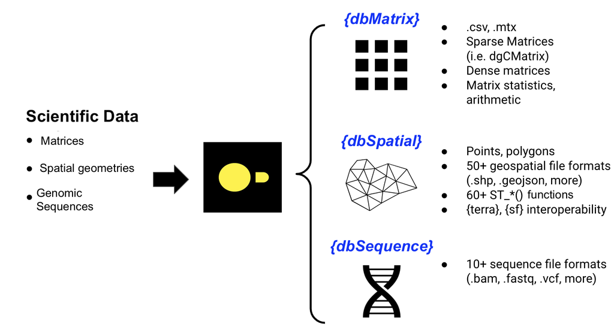

## `{dbverse}` adopts familiar syntax

### Example with `{dbMatrix}`

#### Matrix

```r
rownames(dgc)[1:5]
```

```
[1] "Gna12"  "Ccnd2"  "Btbd17" "Sox9"   "Sez6"
```

```r
colnames(dgc)[1:5]
```

```
[1] "AAAGGGATGTAGCAAG-1" "AAATGGCATGTCTTGT-1" "AAATGGTCAATGTGCC-1"
[4] "AAATTAACGGGTAGCT-1" "AACAACTGGTAGTTGC-1"
```

```r
dim(dgc)
```

```
[1] 634 624
```

#### dbMatrix

```
Loaded dbMatrix
```

```r
rownames(dbMatrix)[1:5]
```

```
[1] "Gna12"  "Ccnd2"  "Btbd17" "Sox9"   "Sez6"
```

```r
colnames(dbMatrix)[1:5]
```

```
[1] "AAAGGGATGTAGCAAG-1" "AAATGGCATGTCTTGT-1" "AAATGGTCAATGTGCC-1"
[4] "AAATTAACGGGTAGCT-1" "AACAACTGGTAGTTGC-1"
```

```r
dim(dgc)
```

```
[1] 634 624
```

## How does it work? *dbMatrix* example

*dbMatrix* adopts familiar `{Matrix}` syntax…

```r
scaled <- dbMatrix[,"cell_1"] * 10
```

with underlying methods implemented with `{dplyr}` …

```r
scaled <- dplyr::tbl(con, "dbMatrix") |>
  dplyr::select(cell_id = "cell_1") |>
  dplyr::mutate(scaled = expression * 10)
```

which are transpiled to SQL via `{dbplyr}`…

```sql
SELECT cell_id, expression * 10 AS scaled
FROM my_cells.db WEHRE cell_id = 'cell_1';
```

and lazy evaluated in a DuckDB database 🐥🚀!

## Illustrative `{dbMatrix}` benchmark

### `{dbMatrix}` performs larger-than-memory sparse matrix operations and outperforms HDF5Matrix

```r
norm_mat <- t(t(dbMatrix) / libsizes) * scalefactor
lib_norm_mat <- log(norm_mat + offset) / log(base)
log_norm_mat <- t(norm_mat) - colMeans(lib_norm_mat)
# ...additional matrix operations
```

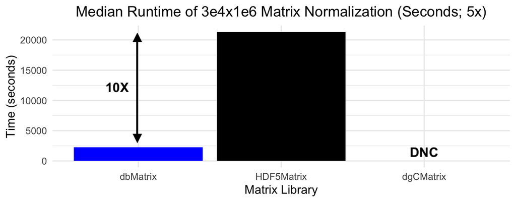

## Illustrative `{dbSpatial}` benchmark

### `{dbSptaial}` outperforms existing in-memory methods for spatial intersections

*Task*: find the intersection between cell polygons in tissue region of interests (ROIs)

Median Runtime (seconds; 5X queries)

|  | No. Polygons | dbSpatial | sf (memory) | Δ Performance |
| --- | --- | --- | --- | --- |
| ROI 1 | 1564 | 0.05 | 0.480 | 9X |
| ROI 2 | 92498 | 1.56 | 39.024 | 25X |
| ROI 3 | 143245 | 2.55 | 65.398 | 25X |

## Illustrative `{dbSequence}` benchmark

### `{dbSequence}` outperforms competing methods

*Task*: filter reads in a genomic `*.bam` file (28GB, 285e6 reads)

- `samtools` v1.20 (Li *et al.* 2009)
- q01: chromosome region
- q02: q01 + flag
- q03: q02 + CIGAR string (`samtools` + `awk`)

Median Runtime (seconds; 5X queries)

| Query | dbSequence | samtools | Δ Speed |
| --- | --- | --- | --- |
| q01 | 0.03400 | 0.08 | 2X |
| q02 | 0.00622 | 0.02 | 3X |
| q03 | 19.26000 | DNC | ∞ |

## Conclusions

### Advantages of using DuckDB for scientific data analysis

- **Runs on modern laptops**: All previous benchmarks were performed on a Macbook Pro M2, 16GB RAM, 512GB SSD
- **Open Source**: MIT license
- **Platform-independent**: Runs on all major OS
- **Portable**: Share results in a single `*.db` file
- **Affordable**: Free to use, pay for more local storage as needed or ‘hybrid execution’ with *MotherDuck*
- **First release**: `08/15/2024` (today 🎉)

## Limitations and future directions

- `dbverse` is currently only compatible with R
  - Plan to support other languages (e.g. Python)
- Limited visualization/plotting functionality
  - `uwdata/mosaic` integration, see discussion #354
- Limited support for large images
  - DuckDB Spatial Extension Raster support
- Plans to adopt `duckplyr`
  - See `duckdblabs/duckplyr` issue #86
- … and much more!

## Acknowledgements

#### Ruben Dries Lab

- **Jiaji George Chen**️
- Iqra Amin
- Wonyl Choi
- Junxiang Xu
- Yibing Michelle Wei
- Jeffrey Sheridan
- Quynh Sun
- Veronica Jarzabek

#### Funding

[figure not shown]

## Questions?

[figure not shown]

*To learn more please visit:*  
https://drieslab.github.io/dbverse/  
🐦👨🏽‍💻@Ed2uiz | ✉️ ecruiz@bu.edu

Link to slides: https://rpubs.com/Ed2uiz/dbverse-duckCon2024